# Supervised Learning Project.

# Thera Bank Personal Loan Campaign

## 1. Import the datasets and libraries, check datatype, statistical summary, shape, null values or incorrect imputation. (5 marks)

```python
## Importing necessary libraries for this assignment.
import pandas as pd
import seaborn as sns
import numpy as np
import matplotlib.pyplot as plt
```

```python
#Reading CSV file for analysis and renaming the dataset.
bank = pd.read_csv("Bank_Personal_Loan_Modelling.csv")
```

```python
#Looking at first 5 observations in dataset.
bank.head()
```

|  | ID | Age | Experience | Income | ZIP Code | Family | CCAvg | Education | Mortgage | Personal Loan | Securities Account | CD Account | Online | CreditCard |
| --- | --- | --- | --- | --- | --- | --- | --- | --- | --- | --- | --- | --- | --- | --- |
| 0 | 1 | 25 | 1 | 49 | 91107 | 4 | 1.6 | 1 | 0 | 0 | 1 | 0 | 0 | 0 |
| 1 | 2 | 45 | 19 | 34 | 90089 | 3 | 1.5 | 1 | 0 | 0 | 1 | 0 | 0 | 0 |
| 2 | 3 | 39 | 15 | 11 | 94720 | 1 | 1.0 | 1 | 0 | 0 | 0 | 0 | 0 | 0 |
| 3 | 4 | 35 | 9 | 100 | 94112 | 1 | 2.7 | 2 | 0 | 0 | 0 | 0 | 0 | 0 |
| 4 | 5 | 35 | 8 | 45 | 91330 | 4 | 1.0 | 2 | 0 | 0 | 0 | 0 | 0 | 1 |

```python
#Data type of variables in the dataset.
bank.dtypes
```

```
ID                      int64
Age                     int64
Experience              int64
Income                  int64
ZIP Code                int64
Family                  int64
CCAvg                 float64
Education               int64
Mortgage                int64
Personal Loan           int64
Securities Account      int64
CD Account              int64
Online                  int64
CreditCard              int64
dtype: object
```

### In the data, there are 14 variables. Thirteen are integer variables, and 1 is a float (which has decimals).

```python
#Descriptive statistics of variables
bank.describe().transpose()
```

|  | count | mean | std | min | 25% | 50% | 75% | max |
| --- | --- | --- | --- | --- | --- | --- | --- | --- |
| ID | 5000.0 | 2500.500000 | 1443.520003 | 1.0 | 1250.75 | 2500.5 | 3750.25 | 5000.0 |
| Age | 5000.0 | 45.338400 | 11.463166 | 23.0 | 35.00 | 45.0 | 55.00 | 67.0 |
| Experience | 5000.0 | 20.104600 | 11.467954 | -3.0 | 10.00 | 20.0 | 30.00 | 43.0 |
| Income | 5000.0 | 73.774200 | 46.033729 | 8.0 | 39.00 | 64.0 | 98.00 | 224.0 |
| ZIP Code | 5000.0 | 93152.503000 | 2121.852197 | 9307.0 | 91911.00 | 93437.0 | 94608.00 | 96651.0 |
| Family | 5000.0 | 2.396400 | 1.147663 | 1.0 | 1.00 | 2.0 | 3.00 | 4.0 |
| CCAvg | 5000.0 | 1.937938 | 1.747659 | 0.0 | 0.70 | 1.5 | 2.50 | 10.0 |
| Education | 5000.0 | 1.881000 | 0.839869 | 1.0 | 1.00 | 2.0 | 3.00 | 3.0 |
| Mortgage | 5000.0 | 56.498800 | 101.713802 | 0.0 | 0.00 | 0.0 | 101.00 | 635.0 |
| Personal Loan | 5000.0 | 0.096000 | 0.294621 | 0.0 | 0.00 | 0.0 | 0.00 | 1.0 |
| Securities Account | 5000.0 | 0.104400 | 0.305809 | 0.0 | 0.00 | 0.0 | 0.00 | 1.0 |
| CD Account | 5000.0 | 0.060400 | 0.238250 | 0.0 | 0.00 | 0.0 | 0.00 | 1.0 |
| Online | 5000.0 | 0.596800 | 0.490589 | 0.0 | 0.00 | 1.0 | 1.00 | 1.0 |
| CreditCard | 5000.0 | 0.294000 | 0.455637 | 0.0 | 0.00 | 0.0 | 1.00 | 1.0 |

### Interpreting ID, and zip code's descriptive statistics do not make sense because the numbers are mainly characters and do not hold any numerical value.

```python
#Shape of data.
bank.shape
```

```
(5000, 14)
```

```python
#Seeing if there are any variables with null values
bank.info()
```

```
<class 'pandas.core.frame.DataFrame'>
RangeIndex: 5000 entries, 0 to 4999
Data columns (total 14 columns):
 #   Column              Non-Null Count  Dtype
---  ------              --------------  -----
 0   ID                  5000 non-null   int64
 1   Age                 5000 non-null   int64
 2   Experience          5000 non-null   int64
 3   Income              5000 non-null   int64
 4   ZIP Code            5000 non-null   int64
 5   Family              5000 non-null   int64
 6   CCAvg               5000 non-null   float64
 7   Education           5000 non-null   int64
 8   Mortgage            5000 non-null   int64
 9   Personal Loan       5000 non-null   int64
 10  Securities Account  5000 non-null   int64
 11  CD Account          5000 non-null   int64
 12  Online              5000 non-null   int64
 13  CreditCard          5000 non-null   int64
dtypes: float64(1), int64(13)
memory usage: 547.0 KB
```

### There are no null values in the data. All cells in the dataset are filled.

```python
#Checking to see unique values in Age, Experience, Income, Family, CCAvg, Education, Mortgage, Personal Loan,
#Securities Account, CD Account, Online and CreditCard
print("Age")
print(np.unique(bank[['Age']].values))
print("")
print("Experience")
print(np.unique(bank[['Experience']].values))
print("")
print("Income")
print(np.unique(bank[['Income']].values))
print("")
print("Family")
print(np.unique(bank[['Family']].values))
print("")
print("CCAvg")
print(np.unique(bank[['CCAvg']].values))
print("")
print("Education")
print(np.unique(bank[['Education']].values))
print("")
print("Mortgage")
print(np.unique(bank[['Mortgage']].values))
print("")
print("Personal Loan")
print(np.unique(bank[['Personal Loan']].values))
print("")
print("Securities Account")
print(np.unique(bank[['Securities Account']].values))
print("")
print("CD Account")
print(np.unique(bank[['CD Account']].values))
print("")
print("Online")
print(np.unique(bank[['Online']].values))
print("")
print("Credit Card")
print(np.unique(bank[['CreditCard']].values))
print("ZIP Code")
print(np.unique(bank['ZIP Code'].values))
```

```
Age
[23 24 25 26 27 28 29 30 31 32 33 34 35 36 37 38 39 40 41 42 43 44 45 46
 47 48 49 50 51 52 53 54 55 56 57 58 59 60 61 62 63 64 65 66 67]

Experience
[-3 -2 -1  0  1  2  3  4  5  6  7  8  9 10 11 12 13 14 15 16 17 18 19 20
 21 22 23 24 25 26 27 28 29 30 31 32 33 34 35 36 37 38 39 40 41 42 43]

Income
[  8   9  10  11  12  13  14  15  18  19  20  21  22  23  24  25  28  29
  30  31  32  33  34  35  38  39  40  41  42  43  44  45  48  49  50  51
  52  53  54  55  58  59  60  61  62  63  64  65  68  69  70  71  72  73
  74  75  78  79  80  81  82  83  84  85  88  89  90  91  92  93  94  95
  98  99 100 101 102 103 104 105 108 109 110 111 112 113 114 115 118 119
 120 121 122 123 124 125 128 129 130 131 132 133 134 135 138 139 140 141
 142 143 144 145 148 149 150 151 152 153 154 155 158 159 160 161 162 163
 164 165 168 169 170 171 172 173 174 175 178 179 180 181 182 183 184 185
 188 189 190 191 192 193 194 195 198 199 200 201 202 203 204 205 218 224]

Family
[1 2 3 4]

CCAvg
[ 0.    0.1   0.2   0.3   0.4   0.5   0.6   0.67  0.7   0.75  0.8   0.9
  1.    1.1   1.2   1.3   1.33  1.4   1.5   1.6   1.67  1.7   1.75  1.8
  1.9   2.    2.1   2.2   2.3   2.33  2.4   2.5   2.6   2.67  2.7   2.75
  2.8   2.9   3.    3.1   3.2   3.25  3.3   3.33  3.4   3.5   3.6   3.67
  3.7   3.8   3.9   4.    4.1   4.2   4.25  4.3   4.33  4.4   4.5   4.6
  4.67  4.7   4.75  4.8   4.9   5.    5.1   5.2   5.3   5.33  5.4   5.5
  5.6   5.67  5.7   5.8   5.9   6.    6.1   6.2   6.3   6.33  6.4   6.5
  6.6   6.67  6.7   6.8   6.9   7.    7.2   7.3   7.4   7.5   7.6   7.8
  7.9   8.    8.1   8.2   8.3   8.5   8.6   8.8   8.9   9.    9.3  10.  ]

Education
[1 2 3]

Mortgage
[  0  75  76  77  78  79  80  81  82  83  84  85  86  87  88  89  90  91
  92  93  94  95  96  97  98  99 100 101 102 103 104 105 106 107 108 109
 110 111 112 113 114 115 116 117 118 119 120 121 122 123 124 125 126 127
```

[output cut: 57 more lines]

```
 94086 94087 94102 94104 94105 94107 94108 94109 94110 94111 94112 94114
 94115 94116 94117 94118 94122 94123 94124 94126 94131 94132 94143 94234
 94301 94302 94303 94304 94305 94306 94309 94402 94404 94501 94507 94509
 94521 94523 94526 94534 94536 94538 94539 94542 94545 94546 94550 94551
 94553 94555 94558 94566 94571 94575 94577 94583 94588 94590 94591 94596
 94598 94604 94606 94607 94608 94609 94610 94611 94612 94618 94701 94703
 94704 94705 94706 94707 94708 94709 94710 94720 94801 94803 94806 94901
 94904 94920 94923 94928 94939 94949 94960 94965 94970 94998 95003 95005
 95006 95008 95010 95014 95020 95023 95032 95035 95037 95039 95045 95051
 95053 95054 95060 95064 95070 95112 95120 95123 95125 95126 95131 95133
 95134 95135 95136 95138 95192 95193 95207 95211 95307 95348 95351 95354
 95370 95403 95405 95422 95449 95482 95503 95518 95521 95605 95616 95617
 95621 95630 95670 95678 95741 95747 95758 95762 95812 95814 95816 95817
 95818 95819 95820 95821 95822 95825 95827 95828 95831 95833 95841 95842
 95929 95973 96001 96003 96008 96064 96091 96094 96145 96150 96651]
```

### From looking at the unique values in the variables of interest, 'Experience' has negative numbers, which does not make any sense. Negative number of years of professional experience does not make sense. Ultimately, these values will need to be newly imputed later on.

## 2. EDA: Study the data distribution in each attribute and target variable, share your findings (20 marks)

## Number of unique in each column?

## Number of people with zero mortgage?

## Number of people with zero credit card spending per month?

## Value counts of all categorical columns.

## Get data model ready

```python
#Number of unique in each column.
bank.nunique()
```

```
ID                    5000
Age                     45
Experience              47
Income                 162
ZIP Code               467
Family                   4
CCAvg                  108
Education                3
Mortgage               347
Personal Loan            2
Securities Account       2
CD Account               2
Online                   2
CreditCard               2
dtype: int64
```

```python
#Subset Mortgage = 0, and make a new dataframe and count the number of 0s
print("Number of Zeroes in Mortgage:")
bank_mortgage = bank[bank['Mortgage'] == 0]
print(bank_mortgage['Mortgage'].value_counts().sum())
#Double check
print("")
print("Double check")
print(bank['Mortgage'].value_counts())
```

```
Number of Zeroes in Mortgage:
3462

Double check
0      3462
98       17
103      16
119      16
83       16
91       16
89       16
90       15
102      15
78       15
118      14
```

[output cut: 337 more lines]

```python
#Subset CreditCard = 0, and make a new dataframe and count the number of 0s
print("Number of Zeroes in CreditCard:")
bank_credit_card = bank[bank['CreditCard'] == 0]
print(bank_credit_card['CreditCard'].value_counts().sum())
#Double check
print("")
print("Double Check")
print(bank['CreditCard'].value_counts())
```

```
Number of Zeroes in CreditCard:
3530

Double Check
0    3530
1    1470
Name: CreditCard, dtype: int64
```

```python
#Categorical variables in dataset include: Family, Education, Personal Loan, Securities Account, CD Account, Online, Credit Card
print("Family")
print(bank['Family'].value_counts())
print("")
print("Education")
print(bank['Education'].value_counts())
print("")
print("Personal Loan")
print(bank['Personal Loan'].value_counts())
print("")
print("Securities Account")
print(bank['Securities Account'].value_counts())
print("")
print("CD Account")
print(bank['CD Account'].value_counts())
print("")
print("Online")
print(bank['Online'].value_counts())
print("")
print("CreditCard")
print(bank['CreditCard'].value_counts())
print("ZIP Code")
print(bank['ZIP Code'].value_counts())
```

```
Family
1    1472
2    1296
4    1222
3    1010
Name: Family, dtype: int64

Education
1    2096
3    1501
2    1403
Name: Education, dtype: int64

Personal Loan
0    4520
```

[output cut: 491 more lines]

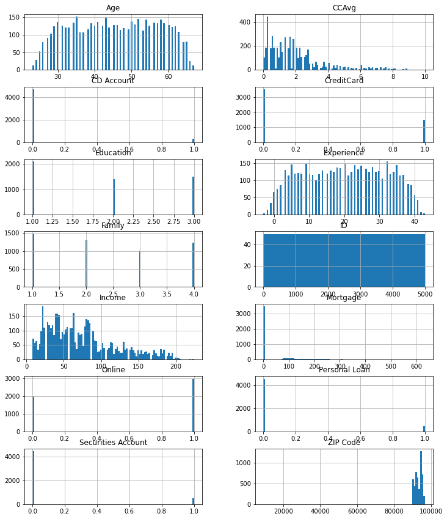

```python
#Univariate analysis
columns = list(bank)[:] # Creating a new list with all columns
bank[columns].hist(stacked=False, bins=100, figsize=(12,30), layout=(14,2)); # Histogram of all columns
```

# From the histograms above, you could see that Age, CCAvg, Experience, and Income are well represented. The income and CCAvg data are right skewed, suggesting the average is higher than the median value.

# Plotting the histograms for ID and Zip Code do not make sense because they are and should be considered string variables.

# The Mortgage variable is somewhat problematic because there is a large amount of zeroes in this variable, and imputation is most likely the better way of handling the zeroes. Unlike the other categorical variables, you could see on the x-axis, this is more likely a numerical continuous variable, and zeroes should be dealt with.

# The other variables are categorical in nature, and plotting them this way is acceptable, but bar charts would have been better.

### BIVARIATE ANALYSIS

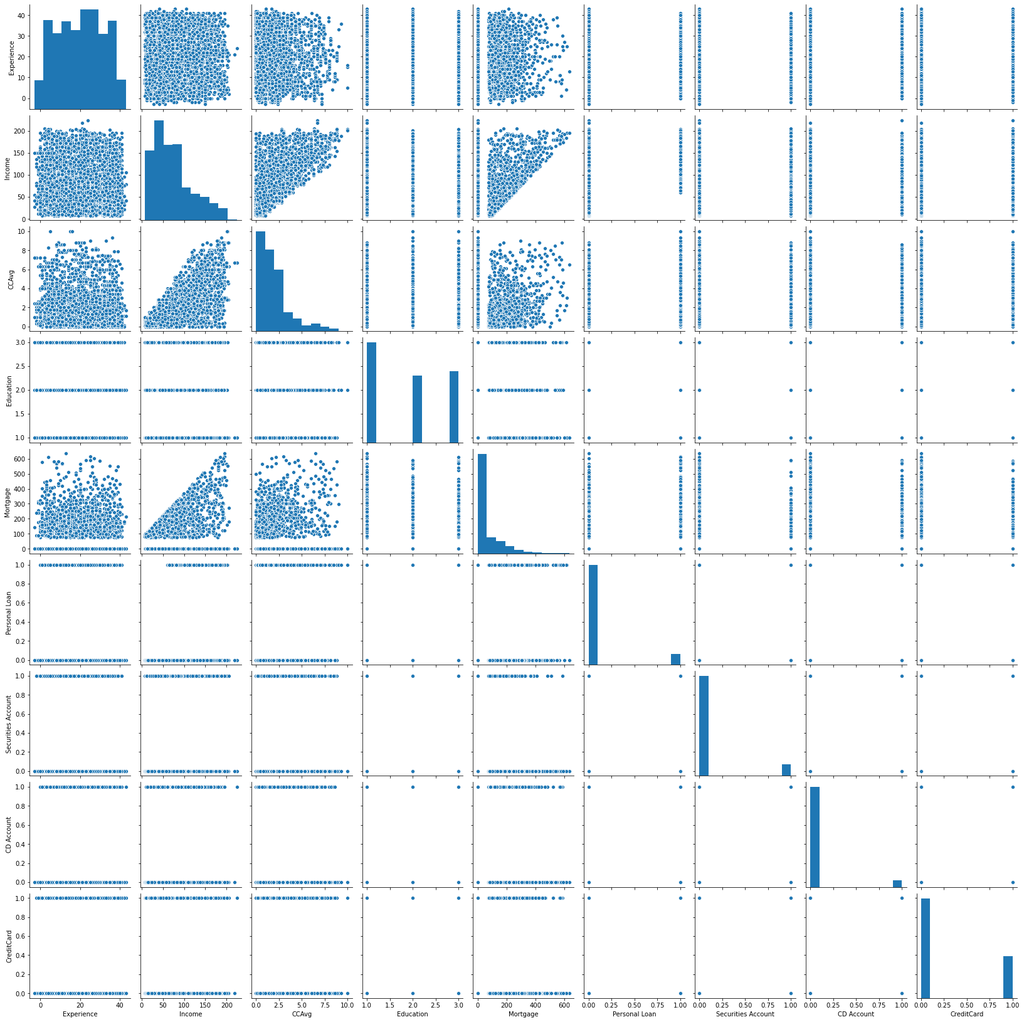

```python
# Pairplot gives us a rough idea of how the variables could be related.
sns.pairplot(bank[['Experience', 'Income', 'CCAvg', 'Education', 'Mortgage', 'Personal Loan', 'Securities Account', 'CD Account', 'CreditCard']]);
```

```python
# Correlation
# A better way to evaluate the relationship between 2 variables is using correlation.
bank.corr()
```

|  | ID | Age | Experience | Income | ZIP Code | Family | CCAvg | Education | Mortgage | Personal Loan | Securities Account | CD Account | Online | CreditCard |
| --- | --- | --- | --- | --- | --- | --- | --- | --- | --- | --- | --- | --- | --- | --- |
| ID | 1.000000 | -0.008473 | -0.008326 | -0.017695 | 0.013432 | -0.016797 | -0.024675 | 0.021463 | -0.013920 | -0.024801 | -0.016972 | -0.006909 | -0.002528 | 0.017028 |
| Age | -0.008473 | 1.000000 | 0.994215 | -0.055269 | -0.029216 | -0.046418 | -0.052012 | 0.041334 | -0.012539 | -0.007726 | -0.000436 | 0.008043 | 0.013702 | 0.007681 |
| Experience | -0.008326 | 0.994215 | 1.000000 | -0.046574 | -0.028626 | -0.052563 | -0.050077 | 0.013152 | -0.010582 | -0.007413 | -0.001232 | 0.010353 | 0.013898 | 0.008967 |
| Income | -0.017695 | -0.055269 | -0.046574 | 1.000000 | -0.016410 | -0.157501 | 0.645984 | -0.187524 | 0.206806 | 0.502462 | -0.002616 | 0.169738 | 0.014206 | -0.002385 |
| ZIP Code | 0.013432 | -0.029216 | -0.028626 | -0.016410 | 1.000000 | 0.011778 | -0.004061 | -0.017377 | 0.007383 | 0.000107 | 0.004704 | 0.019972 | 0.016990 | 0.007691 |
| Family | -0.016797 | -0.046418 | -0.052563 | -0.157501 | 0.011778 | 1.000000 | -0.109275 | 0.064929 | -0.020445 | 0.061367 | 0.019994 | 0.014110 | 0.010354 | 0.011588 |
| CCAvg | -0.024675 | -0.052012 | -0.050077 | 0.645984 | -0.004061 | -0.109275 | 1.000000 | -0.136124 | 0.109905 | 0.366889 | 0.015086 | 0.136534 | -0.003611 | -0.006689 |
| Education | 0.021463 | 0.041334 | 0.013152 | -0.187524 | -0.017377 | 0.064929 | -0.136124 | 1.000000 | -0.033327 | 0.136722 | -0.010812 | 0.013934 | -0.015004 | -0.011014 |
| Mortgage | -0.013920 | -0.012539 | -0.010582 | 0.206806 | 0.007383 | -0.020445 | 0.109905 | -0.033327 | 1.000000 | 0.142095 | -0.005411 | 0.089311 | -0.005995 | -0.007231 |
| Personal Loan | -0.024801 | -0.007726 | -0.007413 | 0.502462 | 0.000107 | 0.061367 | 0.366889 | 0.136722 | 0.142095 | 1.000000 | 0.021954 | 0.316355 | 0.006278 | 0.002802 |
| Securities Account | -0.016972 | -0.000436 | -0.001232 | -0.002616 | 0.004704 | 0.019994 | 0.015086 | -0.010812 | -0.005411 | 0.021954 | 1.000000 | 0.317034 | 0.012627 | -0.015028 |
| CD Account | -0.006909 | 0.008043 | 0.010353 | 0.169738 | 0.019972 | 0.014110 | 0.136534 | 0.013934 | 0.089311 | 0.316355 | 0.317034 | 1.000000 | 0.175880 | 0.278644 |
| Online | -0.002528 | 0.013702 | 0.013898 | 0.014206 | 0.016990 | 0.010354 | -0.003611 | -0.015004 | -0.005995 | 0.006278 | 0.012627 | 0.175880 | 1.000000 | 0.004210 |
| CreditCard | 0.017028 | 0.007681 | 0.008967 | -0.002385 | 0.007691 | 0.011588 | -0.006689 | -0.011014 | -0.007231 | 0.002802 | -0.015028 | 0.278644 | 0.004210 | 1.000000 |

```python
#Correlation
#Correlation Matrix
def plot_corr(bank, size=18):
    corr = bank.corr()
    fig, ax = plt.subplots(figsize=(size, size))
    ax.matshow(corr)
    plt.xticks(range(len(corr.columns)), corr.columns)
    plt.yticks(range(len(corr.columns)), corr.columns)
    for (i, j), z in np.ndenumerate(corr):
        ax.text(j, i, '{:0.1f}'.format(z), ha='center', va='center')
```

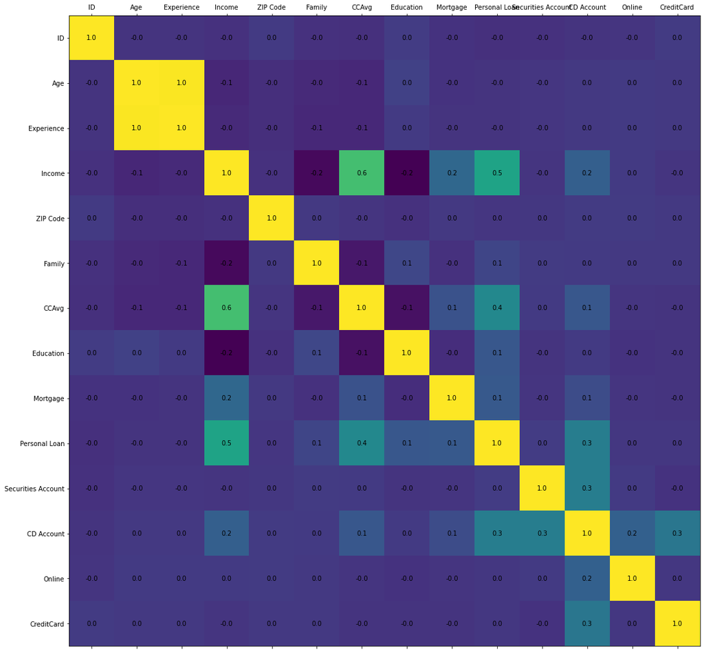

```python
plot_corr(bank)
```

### Correlation Matrix Interpretation

### Yellow suggests highly correlated, while dark blue suggests lowly correlated.

### Age and Experience are highly correlated. To be exact, the Pearson's correlation value for this relationship is: 0.994. Since these two are so highly correlated, if we were to build a multivariate model, we should only include 1 of these, since the addition of the second variable would more likely not contribute much towards improving the model's performance.

### CCAvg and Income have a Pearson's correlation value of 0.6.

### Personal Loan and Income have a Pearson's correlation value of 0.5

### Personal Loan and CCAvg have a Pearson's correlation value of 0.4

# Crosstabs to evaluate bivariate relationships.

## Continuous Variables:

```python
#I will only evaluate the mean for numerical continuous variables: Age, Experience, Income, CCAvg. and Mortgage
bank.groupby(["Personal Loan"]).mean()
```

| Personal Loan | ID | Age | Experience | Income | ZIP Code | Family | CCAvg | Education | Mortgage | Securities Account | CD Account | Online | CreditCard |
| --- | --- | --- | --- | --- | --- | --- | --- | --- | --- | --- | --- | --- | --- |
| 0 | 2512.165487 | 45.367257 | 20.132301 | 66.237389 | 93152.428761 | 2.373451 | 1.729009 | 1.843584 | 51.789381 | 0.102212 | 0.035841 | 0.595796 | 0.293584 |
| 1 | 2390.650000 | 45.066667 | 19.843750 | 144.745833 | 93153.202083 | 2.612500 | 3.905354 | 2.233333 | 100.845833 | 0.125000 | 0.291667 | 0.606250 | 0.297917 |

### The average income, CCAvg, and Mortgage were a lot higher for those who were offered and accepted the personal loan from last campaign. Age and experience did not differ too much between those who took out loans and those who didn't.

```python
#I will also only evaluate the median for numerical continuous variables: Age, Experience, Income, CCAvg. and Mortgage
bank.groupby(["Personal Loan"]).median()
```

| Personal Loan | ID | Age | Experience | Income | ZIP Code | Family | CCAvg | Education | Mortgage | Securities Account | CD Account | Online | CreditCard |
| --- | --- | --- | --- | --- | --- | --- | --- | --- | --- | --- | --- | --- | --- |
| 0 | 2518.5 | 45.0 | 20.0 | 59.0 | 93437.0 | 2.0 | 1.4 | 2.0 | 0.0 | 0.0 | 0.0 | 1.0 | 0.0 |
| 1 | 2342.0 | 45.0 | 20.0 | 142.5 | 93407.0 | 3.0 | 3.8 | 2.0 | 0.0 | 0.0 | 0.0 | 1.0 | 0.0 |

### The median showed similar results as the mean did for all variables except Mortgage. Mortgage has a 0 median for both groups due to the excessive 0s. The reason why there are such high average values for the mortgage variable is because average is highly impacted by outliers. Mortgage may be a variable that should not be included into the model due to its excessive 0s, and outlier values.

## Categorical Variables

```python
pd.crosstab(bank['Family'],bank['Personal Loan'],normalize='columns')
```

| Personal Loan Family | 0 | 1 |
| --- | --- | --- |
| 1 | 0.301991 | 0.222917 |
| 2 | 0.263274 | 0.220833 |
| 3 | 0.194027 | 0.277083 |
| 4 | 0.240708 | 0.279167 |

### Families with more family members seem to take more personal loans and families with less family members take less personal loans.

```python
pd.crosstab(bank['Education'],bank['Personal Loan'],normalize='columns')
```

| Personal Loan Education | 0 | 1 |
| --- | --- | --- |
| 1 | 0.443142 | 0.193750 |
| 2 | 0.270133 | 0.379167 |
| 3 | 0.286726 | 0.427083 |

### It seems that loans are offered and accepted more by individuals with more education than with less education.

```python
pd.crosstab(bank['Online'],bank['Personal Loan'],normalize='columns')
```

| Personal Loan Online | 0 | 1 |
| --- | --- | --- |
| 0 | 0.404204 | 0.39375 |
| 1 | 0.595796 | 0.60625 |

### Online users have the same distribution when it comes to taking or not taking personal loans. The same trend is observed among non-online users.

```python
pd.crosstab(bank['Securities Account'],bank['Personal Loan'],normalize='columns')
```

| Personal Loan Securities Account | 0 | 1 |
| --- | --- | --- |
| 0 | 0.897788 | 0.875 |
| 1 | 0.102212 | 0.125 |

### Those that have a securities account are taking slightly more personal loans.

```python
pd.crosstab(bank['CD Account'],bank['Personal Loan'],normalize='columns')
```

| Personal Loan CD Account | 0 | 1 |
| --- | --- | --- |
| 0 | 0.964159 | 0.708333 |
| 1 | 0.035841 | 0.291667 |

### Those that have a CD account are taking more personal loans.

```python
pd.crosstab(bank['CreditCard'],bank['Personal Loan'],normalize='columns')
```

| Personal Loan CreditCard | 0 | 1 |
| --- | --- | --- |
| 0 | 0.706416 | 0.702083 |
| 1 | 0.293584 | 0.297917 |

### Credit card holders have the same distribution when it comes to taking or not taking personal loans. The same trend is observed among non-credit card holders.

```python
pd.crosstab(bank['ZIP Code'],bank['Personal Loan'],normalize='columns')
```

| Personal Loan ZIP Code | 0 | 1 |
| --- | --- | --- |
| 9307 | 0.000221 | 0.000000 |
| 90005 | 0.001106 | 0.000000 |
| 90007 | 0.001327 | 0.000000 |
| 90009 | 0.001770 | 0.000000 |
| 90011 | 0.000664 | 0.000000 |
| 90016 | 0.000221 | 0.002083 |
| 90018 | 0.000885 | 0.000000 |
| 90019 | 0.000885 | 0.002083 |
| 90024 | 0.010841 | 0.002083 |
| 90025 | 0.003761 | 0.004167 |
| 90027 | 0.000442 | 0.002083 |
| 90028 | 0.001549 | 0.002083 |
| 90029 | 0.001106 | 0.000000 |
| 90032 | 0.001549 | 0.002083 |
| 90033 | 0.001991 | 0.000000 |
| 90034 | 0.004204 | 0.002083 |
| 90035 | 0.001327 | 0.000000 |
| 90036 | 0.001549 | 0.000000 |
| 90037 | 0.000885 | 0.002083 |
| 90041 | 0.002212 | 0.000000 |
| 90044 | 0.000442 | 0.000000 |
| 90045 | 0.000664 | 0.000000 |
| 90048 | 0.000885 | 0.000000 |
| 90049 | 0.001327 | 0.006250 |
| 90057 | 0.000442 | 0.002083 |
| 90058 | 0.001327 | 0.000000 |
| 90059 | 0.000442 | 0.004167 |
| 90064 | 0.002655 | 0.004167 |
| 90065 | 0.001327 | 0.004167 |
| 90066 | 0.001327 | 0.000000 |

[output cut: 437 more lines]

### For all zip codes, there seems to not be a difference between those who take personal loans and those who don't. There are too few cases for each zip code to tell if there's a difference between those who got loans and those who didn't. All results are very close to 0.

```python
# Getting Data Model Ready: 1. Replace negative values in Experience with the mean years of Experience.
                          # Sidenote: Mortgage has excessive 0s for a continuous variable. If I were tasked with using this dataset as a small sample to predict the outcomes of a large population, I would impute a fraction of the zeroes in Mortgage to match the population that had 0 mortgages. Since that is not what we are trying to accomplish here, I will not impute that variable and will eliminate it from the model all together.

#Impute Experience average for the negative values.
from sklearn.impute import SimpleImputer
rep_neg3 = SimpleImputer(missing_values=-3, strategy="mean")
cols=['Experience']
imputer = rep_neg3.fit(bank[cols])
bank[cols] = imputer.transform(bank[cols])

rep_neg2 = SimpleImputer(missing_values=-2, strategy="mean")
cols=['Experience']
imputer = rep_neg2.fit(bank[cols])
bank[cols] = imputer.transform(bank[cols])

rep_neg1 = SimpleImputer(missing_values=-1, strategy="mean")
cols=['Experience']
imputer = rep_neg1.fit(bank[cols])
bank[cols] = imputer.transform(bank[cols])

#Double check
print("Experience")
print(np.unique(bank[['Experience']].values))
print(bank['Experience'].value_counts())
bank['Experience'].mean()
#The mean values differ based on the removal of these negative values from the dataset. However, the means are very close to one another and range from 20.12-20.33.
```

```
Experience
[ 0.  1.  2.  3.  4.  5.  6.  7.  8.  9. 10. 11. 12. 13. 14. 15. 16. 17.
 18. 19. 20. 21. 22. 23. 24. 25. 26. 27. 28. 29. 30. 31. 32. 33. 34. 35.
 36. 37. 38. 39. 40. 41. 42. 43.]
32.0    154
20.0    148
9.0     147
5.0     146
23.0    144
35.0    143
25.0    142
28.0    138
18.0    137
19.0    135
26.0    134
24.0    131
3.0     129
16.0    127
14.0    127
30.0    126
27.0    125
34.0    125
17.0    125
22.0    124
29.0    124
7.0     121
8.0     119
15.0    119
6.0     119
0.0     118
10.0    118
13.0    117
33.0    117
37.0    116
11.0    116
36.0    114
4.0     113
21.0    113
31.0    104
12.0    102
38.0     88
2.0      85
39.0     85
1.0      74
40.0     57
41.0     43
42.0      8
43.0      3
Name: Experience, dtype: int64
```

```
20.1196
```

# 3. Split the data into training and test set in the ratio of 70:30 respectively (5 marks)

```python
from sklearn.model_selection import train_test_split


# I will drop age, id, zip code and mortgage from my list of indepdent variable predictors.
# Reasons: 1. Age is highly correlated with 'Experience' from Correlation matrix (Pearson's corr = 1). Age doesn't show true independence from Experience.
#          2. ID is just an identifier, is different for each case and holds no predictive value for the model.
#          3. ZIP code should not be in the model because there are too few cases reported in each zip code for any of the calculations to mean anything. In the bivariate analysis, it was difficult to interpret anything because the results were all close to 0.
#          4. Mortgage is not a reliable variable. It has excessive zeroes and has high outliers.
X = bank.drop(['Personal Loan', 'Age', 'ID', 'ZIP Code', 'Mortgage'], axis=1)     # Separate predictor variables (independent variables) from outcome (dependent variable)
Y = bank['Personal Loan']   # Predicted class (1=True, 0=False)

#Make dummy variable out of the categorical predictor variables
X = pd.get_dummies(X, drop_first=True)

x_train, x_test, y_train, y_test = train_test_split(X, Y, test_size=0.3, random_state=1)    #Splitting 70:30
# 1 equals any random seed number

x_train.head()
```

|  | Experience | Income | Family | CCAvg | Education | Securities Account | CD Account | Online | CreditCard |
| --- | --- | --- | --- | --- | --- | --- | --- | --- | --- |
| 1334 | 22 | 35 | 2 | 1.3 | 1 | 0 | 0 | 1 | 0 |
| 4768 | 14 | 39 | 1 | 2.0 | 2 | 0 | 0 | 1 | 0 |
| 65 | 35 | 131 | 1 | 3.8 | 1 | 0 | 0 | 1 | 1 |
| 177 | 3 | 65 | 4 | 1.8 | 2 | 0 | 0 | 0 | 0 |
| 4489 | 13 | 21 | 3 | 0.2 | 2 | 0 | 0 | 1 | 0 |

```python
#Verifying if 70% is training data and 30% is test data

print("{0:0.2f}% data is in training set".format((len(x_train)/len(bank.index)) * 100))
print("{0:0.2f}% data is in test set".format((len(x_test)/len(bank.index)) * 100))
```

```
70.00% data is in training set
30.00% data is in test set
```

```python
#Seing the distribution of values after data splitting

print("Original Personal Loan True Values    : {0} ({1:0.2f}%)".format(len(bank.loc[bank['Personal Loan'] == 1]), (len(bank.loc[bank['Personal Loan'] == 1])/len(bank.index)) * 100))
print("Original Personal Loan False Values   : {0} ({1:0.2f}%)".format(len(bank.loc[bank['Personal Loan'] == 0]), (len(bank.loc[bank['Personal Loan'] == 0])/len(bank.index)) * 100))
print("")
print("Training Personal Loan True Values    : {0} ({1:0.2f}%)".format(len(y_train[y_train[:] == 1]), (len(y_train[y_train[:] == 1])/len(y_train)) * 100))
print("Training Personal Loan False Values   : {0} ({1:0.2f}%)".format(len(y_train[y_train[:] == 0]), (len(y_train[y_train[:] == 0])/len(y_train)) * 100))
print("")
print("Test Personal Loan True Values        : {0} ({1:0.2f}%)".format(len(y_test[y_test[:] == 1]), (len(y_test[y_test[:] == 1])/len(y_test)) * 100))
print("Test Personal Loan False Values       : {0} ({1:0.2f}%)".format(len(y_test[y_test[:] == 0]), (len(y_test[y_test[:] == 0])/len(y_test)) * 100))
print("")
```

```
Original Personal Loan True Values    : 480 (9.60%)
Original Personal Loan False Values   : 4520 (90.40%)

Training Personal Loan True Values    : 331 (9.46%)
Training Personal Loan False Values   : 3169 (90.54%)

Test Personal Loan True Values        : 149 (9.93%)
Test Personal Loan False Values       : 1351 (90.07%)
```

# 4. Use the Logistic Regression model to predict whether the customer will take a personal loan or not. Print all the metrics related to evaluating the model performance (accuracy, recall, precision, f1score, and roc_auc_score). Draw a heatmap to display confusion matrix (15 marks)

```python
#Importing Logistic Regression from sklearn

from sklearn import metrics

from sklearn.linear_model import LogisticRegression

# Fit the model on train
model = LogisticRegression(solver="liblinear")
model.fit(x_train, y_train)
#predict on test
y_predict = model.predict(x_test)
```

```python
#Looking at the model_score
model_score = model.score(x_test, y_test)

print(model_score)
```

```
0.9433333333333334
```

```
Numbers from Confusion Matrix
[[  77   72]
 [  13 1338]]

Confusion Matrix
```

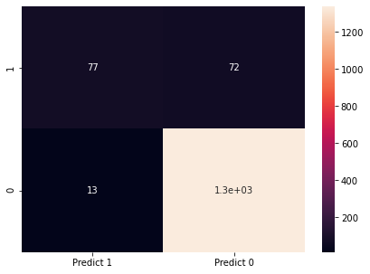

```python
#Finding the actual true positive, true negative, false positive and false negative values

cm=metrics.confusion_matrix(y_test, y_predict, labels=[1, 0])
print("Numbers from Confusion Matrix")
print(cm)
df_cm = pd.DataFrame(cm, index = [i for i in ["1","0"]],
                  columns = [i for i in ["Predict 1","Predict 0"]])
plt.figure(figsize = (7,5))
sns.heatmap(df_cm, annot=True)
print("")

#Confusion Matrix
print("Confusion Matrix")
def draw_cm( actual, predicted ):
    cm = confusion_matrix( actual, predicted)
    sns.heatmap(cm, annot=True,  fmt='.2f', xticklabels = [0,1] , yticklabels = [0,1] )
    plt.ylabel('Observed')
    plt.xlabel('Predicted')
    plt.show()
```

```python
from sklearn.metrics import confusion_matrix, recall_score, precision_score, f1_score, roc_auc_score,accuracy_score

print("Trainig accuracy",model.score(x_train,y_train))
print()
print("Testing accuracy",model.score(x_test, y_test))
print()
print("Recall:",recall_score(y_test,y_predict))
print()
print("Precision:",precision_score(y_test,y_predict))
print()
print("F1 Score:",f1_score(y_test,y_predict))
print()
print("Roc Auc Score:",roc_auc_score(y_test,y_predict))
```

```
Trainig accuracy 0.9505714285714286

Testing accuracy 0.9433333333333334

Recall: 0.5167785234899329

Precision: 0.8555555555555555

F1 Score: 0.6443514644351466

Roc Auc Score: 0.753578010819726
```

# 5. Find out coefficients of all the attributes and show the output in a data frame with column names? For test data show all the rows where the predicted class is not equal to the observed class. (10 marks)

```python
## Feature Importance or Coefficients
fi = pd.DataFrame()
fi['Col'] = x_train.columns
fi['Coeff'] = np.round(abs(model.coef_[0]),2)
fi.sort_values(by='Coeff',ascending=False)
```

|  | Col | Coeff |
| --- | --- | --- |
| 6 | CD Account | 3.15 |
| 4 | Education | 1.18 |
| 8 | CreditCard | 1.01 |
| 5 | Securities Account | 0.94 |
| 7 | Online | 0.62 |
| 2 | Family | 0.46 |
| 3 | CCAvg | 0.13 |
| 1 | Income | 0.04 |
| 0 | Experience | 0.01 |

### From the above syntax of coefficients, CD Account, Education, CreditCard, and Securities Account had the most impact on the making of this model. Other less contributive predictors include: Online, Family, CCAvg, Income and Experience.

### These coefficients are derived from the independent variables in the training data that make up the prediction model.

### Sidenote: In order to statistically infer causation between the independent variables (predictors) and the outcome (dependent variables), you would need to include the y variable and have syntax like the following:

import statsmodels.api as sm

logitmodel=sm.Logit(y_train, x_train)

result=logitmodel.fit()

print(result.summary())

### Running this code and evaluating the p-values and confidence intervals may also lead to better selective combination of predictors.

```python
predict= x_test.copy()
predict['Observed Personal Loan Status'] = y_test
predict['Predicted Personal Loan Status'] = y_predict

# Showing rows where predicted does not equal observed.
pd.set_option("display.max_rows", None, "display.max_columns", None)
predict.loc[predict['Observed Personal Loan Status'] != predict['Predicted Personal Loan Status']]
```

|  | Experience | Income | Family | CCAvg | Education | Securities Account | CD Account | Online | CreditCard | Observed Personal Loan Status | Predicted Personal Loan Status |
| --- | --- | --- | --- | --- | --- | --- | --- | --- | --- | --- | --- |
| 4377 | 8 | 145 | 1 | 2.70 | 3 | 0 | 0 | 1 | 0 | 1 | 0 |
| 3271 | 27 | 93 | 4 | 4.10 | 2 | 0 | 0 | 0 | 1 | 1 | 0 |
| 349 | 2 | 60 | 2 | 3.00 | 1 | 0 | 0 | 0 | 0 | 1 | 0 |
| 927 | 40 | 95 | 3 | 3.70 | 2 | 0 | 0 | 0 | 1 | 1 | 0 |
| 2968 | 18 | 162 | 4 | 1.30 | 1 | 0 | 0 | 0 | 0 | 1 | 0 |
| 1626 | 6 | 180 | 2 | 6.70 | 1 | 0 | 0 | 0 | 0 | 0 | 1 |
| 1518 | 17 | 64 | 4 | 3.00 | 3 | 0 | 0 | 1 | 0 | 1 | 0 |
| 1552 | 5 | 195 | 1 | 4.30 | 1 | 0 | 0 | 0 | 0 | 0 | 1 |
| 2478 | 5 | 178 | 2 | 6.70 | 1 | 0 | 0 | 0 | 0 | 0 | 1 |
| 2784 | 9 | 115 | 4 | 2.20 | 2 | 0 | 0 | 0 | 0 | 1 | 0 |
| 1277 | 20 | 194 | 2 | 8.80 | 1 | 0 | 0 | 0 | 0 | 0 | 1 |
| 1064 | 17 | 138 | 3 | 6.90 | 2 | 0 | 0 | 1 | 0 | 1 | 0 |
| 57 | 31 | 131 | 2 | 1.20 | 3 | 0 | 0 | 0 | 0 | 1 | 0 |
| 4302 | 27 | 85 | 3 | 3.40 | 3 | 0 | 0 | 0 | 0 | 1 | 0 |
| 1822 | 23 | 112 | 1 | 5.10 | 2 | 1 | 1 | 1 | 0 | 1 | 0 |
| 941 | 13 | 129 | 4 | 4.40 | 1 | 0 | 0 | 0 | 0 | 1 | 0 |
| 3467 | 37 | 149 | 2 | 0.20 | 3 | 0 | 0 | 1 | 0 | 1 | 0 |
| 1784 | 29 | 119 | 3 | 2.00 | 1 | 1 | 1 | 0 | 0 | 1 | 0 |
| 1579 | 5 | 122 | 4 | 3.00 | 1 | 0 | 0 | 0 | 1 | 1 | 0 |
| 1177 | 3 | 71 | 1 | 3.30 | 2 | 1 | 1 | 1 | 0 | 1 | 0 |
| 4016 | 28 | 173 | 4 | 2.70 | 1 | 0 | 0 | 1 | 0 | 1 | 0 |
| 3784 | 6 | 115 | 4 | 3.80 | 2 | 0 | 0 | 1 | 0 | 1 | 0 |
| 4590 | 34 | 151 | 3 | 0.60 | 2 | 0 | 0 | 0 | 0 | 1 | 0 |
| 322 | 39 | 101 | 1 | 3.90 | 1 | 1 | 1 | 1 | 0 | 1 | 0 |
| 2158 | 25 | 83 | 4 | 3.10 | 1 | 0 | 0 | 0 | 1 | 1 | 0 |
| 1768 | 18 | 128 | 4 | 5.30 | 1 | 0 | 0 | 0 | 0 | 1 | 0 |
| 1577 | 8 | 65 | 1 | 3.00 | 1 | 0 | 0 | 1 | 0 | 1 | 0 |
| 2024 | 12 | 113 | 4 | 0.20 | 1 | 0 | 0 | 0 | 0 | 1 | 0 |
| 1499 | 26 | 91 | 1 | 4.30 | 2 | 0 | 1 | 1 | 1 | 1 | 0 |
| 3720 | 39 | 131 | 3 | 2.60 | 3 | 0 | 0 | 1 | 0 | 1 | 0 |

[output cut: 55 more lines]

# 6. Give conclusion related to the Business understanding of your model? (5 marks)

Logistic regression may not be the most suitable model for the data. Here are the reasons why:

Important metric: In order for the bank to secure less of a loss, we need to rely on recall and precision as important metrics. Recall determines of all who accept the loan, how many will the model predict accurately. In this case, the recall value is 0.517. 1-Recall (0.483) determines the severity of false negatives. This value is decent. Larger false negative count is bad for the bank, as these are individuals that were predicted to not take the personal loan but they end up accepting it. So, the bank would have to provide loans and take a risk on these individuals that were not predicted by the model to accept it in the first place. In summary, the bank may have to lose money by lending to these 72 individuals (False negative count).

At least with this model, there were more true positives than false negatives.

Precision is also an important metric. It determines of all the cases the model predicted would accept the personal loan, how many will actually accept the loan. Precision for this model is: 0.8556. 1-Precision(0.1444) allows us to understand how the bank can save money on these loans. Individuals accounted for in 1-Precision are people who were predicted to take a loan but ended up not taking it; so the bank would not have to take a gamble on these individuals. There are 13 individuals in this group (False Positive) and the bank would save money.

According to this model, the bank would lose some money overall because there are more false negatives than false positives. This model predicts that the bank would have to pay for 59 additional personal loans (False Negative - False Positive = 72-13).